# Analysis of Alcohol consumption in two Portugese secondary schools

Jussi Jaatinen

# Analysis of Alcohol consumption in two Portugese secondary schools

### Data, hyphotheses and selected explanatory variables

The data of this study has been collected from two Portugese second grade schools by using school reports and questionnaires. Aim of this analysis is to find relationships between high alcohol consumption and hypothesized explanatory variables.

Hyphotheses:

- Males consume more alcohol
- It is more common to use alcohol with friends outside home
- Good family relations decrease drinking
- Drinking may cause absences

According to hyphotheses, the selected explanatory variables are sex, go out, family relations and absences. According to first hyphothesis, all analyses have been divided to two groups, females and males.

In dataset there are lot of background variables like demographic, social relationships, parents´education and employment, or living area as well as grades, absences or health.

Full descriptions of study is available here: https://archive.ics.uci.edu/ml/datasets/Student+Performance.

### All variables and distributions

Observations about selected explanatory variables:

- Sex: Student’s sex, 198 females, 184 males (‘F’ - female or ‘M’ - male)
- Goout: Going out with friends, quite normally distributed, median 3 (1 - very low, 5 - very high)
- Famrel: Quality of family relationships, negatively skewed, median 4 (1 - very bad, 5 - excellent)
- Absences: Number of school absences, multimodal, not normally distributed, median 3 (min. 0 - max. 45)

For alcohol consumption related study, the original data has been modified by combining and averaging weekend and weekdays alcohol consumptions. As result two new variables have been created: alc_use (Likert, 1-5, where 1 = very low, 5 = very high) and high_use (logical, TRUE > 2).

Total number of variables after adding is 35. Number of observations is 382. All variables and their distributions can be seen below.

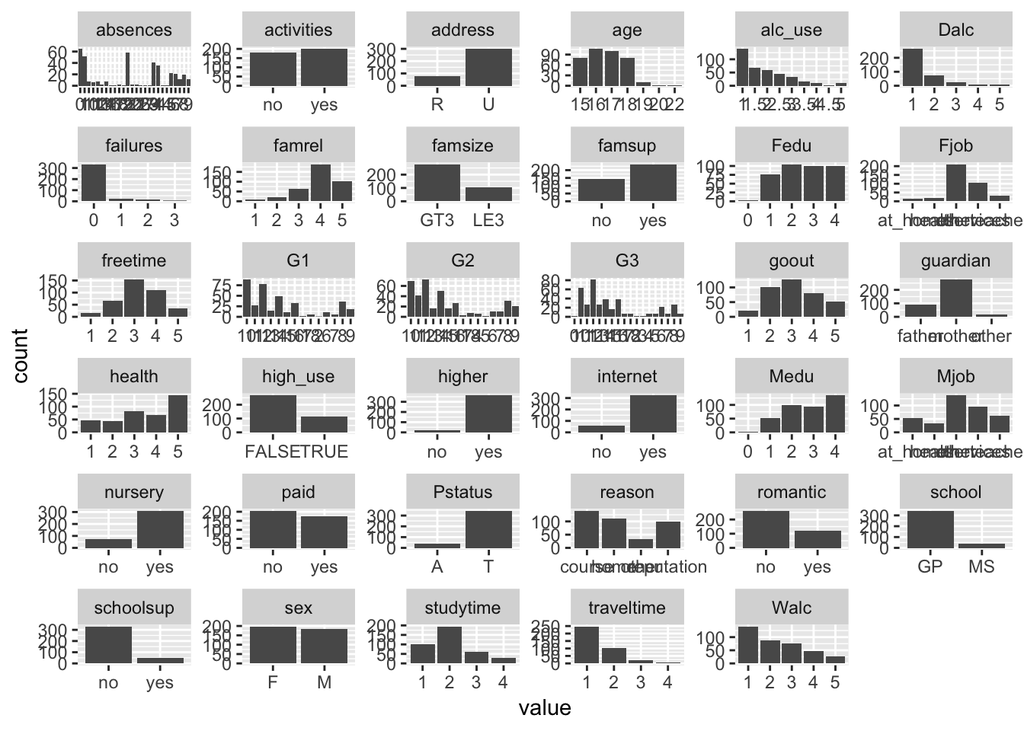

### Distributions and observations of chosen variables

##### Relationship between alcohol consumption and sex

As seen in table below, in generally, males consume more alcohol. In low consumption group (very low or low = FALSE), 58% were females and 42% males, whereas in higher consumption group only 37% were females and 63% males.

```
      FALSE TRUE Sum
  F     156   42 198
  M     112   72 184
  Sum   268  114 382
```

##### Relationship between alcohol consumption and going out with friends

Having more freetime outside home with friends increases alcohol consumption in both sexes significantly.

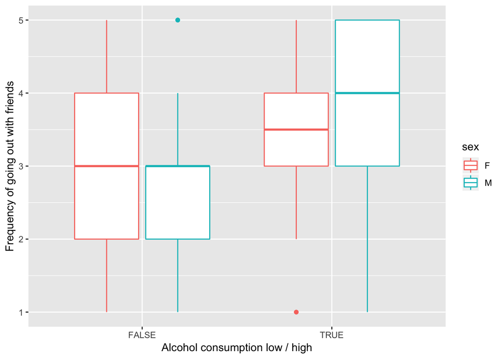

##### Relationship between alcohol consumption and absences

Although absences increase due to higher alcohol consumption, difference is quite moderate, thus larger in males.

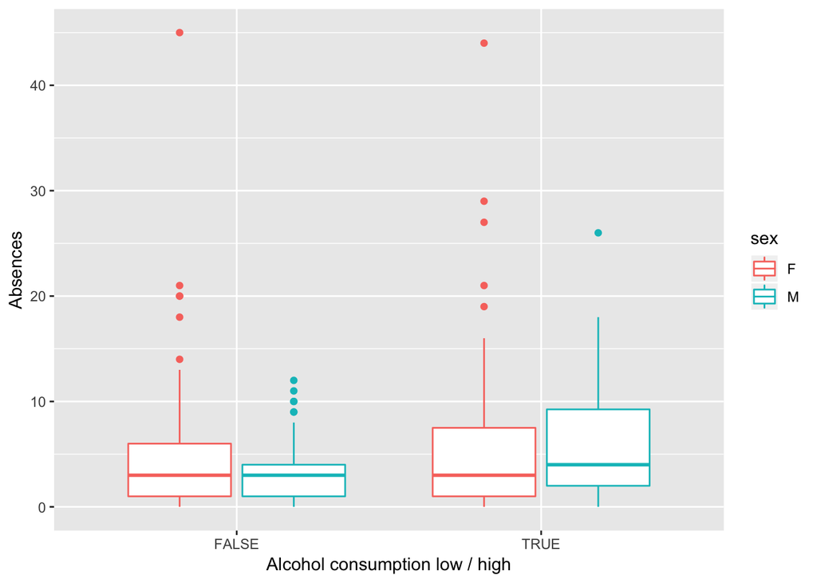

##### Relationship between alcohol consumption and family relations

Although same tendency occur also in this case, there also might be two-sided correlation between alcohol consumption and family relations. Which of them is more cause or consequence is unclear. Bad relationships in family may lead bigger alcohol consumption, but also drinking may evoke collisions between family members.

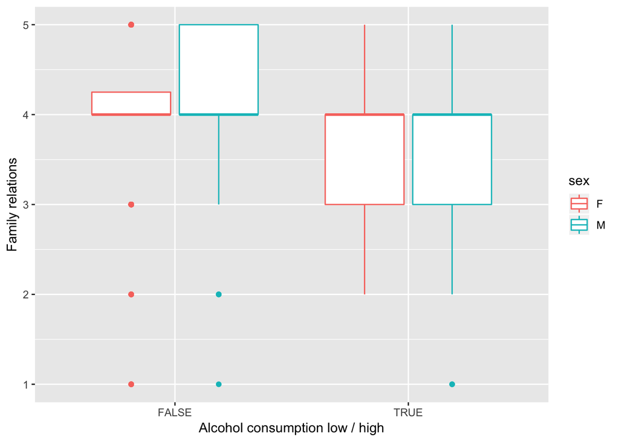

### Logistic regression

In logistic binomial regression selected explanatory variables (discret or continuous) explain dependent binary (high_use) variable. In this case, dependent variable is categorical, alcohol high use (high_use). It has constructed by classifying aforementioned alc_use variable. Values 1 and 2 of alc_use have been classified to low or false and values 3 - 5 to high or true.

```
Call:
glm(formula = high_use ~ famrel + absences + sex + goout, family = "binomial",
    data = alc)

Deviance Residuals:
    Min       1Q   Median       3Q      Max
-1.7151  -0.7820  -0.5137   0.7537   2.5463

Coefficients:
            Estimate Std. Error z value Pr(>|z|)
(Intercept) -2.76826    0.66170  -4.184 2.87e-05 ***
famrel      -0.39378    0.14035  -2.806 0.005020 **
absences     0.08168    0.02200   3.713 0.000205 ***
sexM         1.01234    0.25895   3.909 9.25e-05 ***
goout        0.76761    0.12316   6.232 4.59e-10 ***
---
Signif. codes:  0 '***' 0.001 '**' 0.01 '*' 0.05 '.' 0.1 ' ' 1

(Dispersion parameter for binomial family taken to be 1)

    Null deviance: 465.68  on 381  degrees of freedom
Residual deviance: 379.81  on 377  degrees of freedom
AIC: 389.81

Number of Fisher Scoring iterations: 4
```

```
                    OR      2.5 %    97.5 %
(Intercept) 0.06277092 0.01648406 0.2225470
famrel      0.67449969 0.51060362 0.8869199
absences    1.08510512 1.04012840 1.1353940
sexM        2.75203774 1.66768032 4.6128191
goout       2.15461275 1.70345866 2.7639914
```

### Predictive power of the model

With chosen variables, predictive power of model (penalty) is ~ 0.20 (TRUE-FALSE + FALSE-TRUE pairs summed). This means that about 4/5 of predictions are correct (TRUE-TRUE + FALSE-FALSE pairs summed).

```
        prediction
high_use      FALSE       TRUE        Sum
   FALSE 0.66492147 0.03664921 0.70157068
   TRUE  0.16753927 0.13089005 0.29842932
   Sum   0.83246073 0.16753927 1.00000000
```

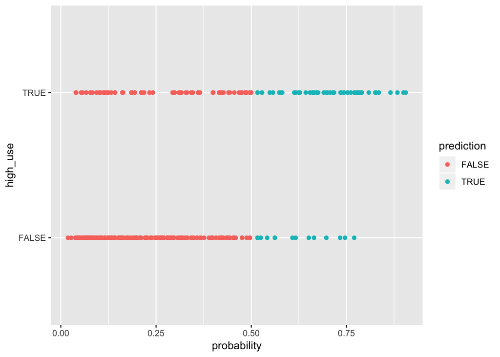

##### Mean prediction error

Mean prediction error of the model (loss function). This is determined by calculating propability of incorrect predictions.

```
[1] 0.2041885
```

### K-fold cross-validation

For testing power of the chosen model, a method called cross-validation can be used. In cross validation sample data has been divided to test and train sections. This means that for example data is divided to 5 equal size parts and 4/5 is used as train data and 1/5 as test data. That is called 5-fold cross-validation. In K-fold CV data has divided to K parts, in this case K = number of observations. So, train data includes K-1 observations and test data 1 observations. In this function this process is circulated so all parts of data is in turn either train or test data.

In this case, K-fold cross-validation gives slighly higher prediction error (0.21) compared to mean prediction error.

```
[1] 0.2146597
```

### 10-fold cross-validation on my model.

This model have smaller prediction error (0.20) using 10-fold cross-validation compared to the model introduced in DataCamp (which had about 0.26 error). This means that chosen variables in my model predict better high alcohol consumption.

```
[1] 0.2068063
```

### Cross-validation to compare the performance of different logistic regression models

```
                    OR      2.5 %    97.5 %
(Intercept) 0.06277092 0.01648406 0.2225470
famrel      0.67449969 0.51060362 0.8869199
absences    1.08510512 1.04012840 1.1353940
sexM        2.75203774 1.66768032 4.6128191
goout       2.15461275 1.70345866 2.7639914
[1] 0.2146597
                   OR     2.5 %    97.5 %
(Intercept) 0.4877368 0.1702903 1.3635949
famrel      0.7475910 0.5811204 0.9595347
absences    1.0980228 1.0524564 1.1504519
sexM        2.7976292 1.7476499 4.5467291
[1] 0.2539267
                   OR     2.5 %   97.5 %
(Intercept) 0.7187304 0.2621851 1.935500
famrel      0.7857743 0.6158556 1.001830
absences    1.0905430 1.0452818 1.142647
[1] 0.2827225
                   OR     2.5 %    97.5 %
(Intercept) 1.1938851 0.4610715 3.0668110
famrel      0.7673146 0.6041200 0.9734032
[1] 0.2984293
                    OR       2.5 %     97.5 %
(Intercept) 0.01555815 0.005885392 0.03804621
absences    1.08782902 1.042458467 1.13933894
sexM        2.60835292 1.593132148 4.33151387
goout       2.07468346 1.650182481 2.64111050
[1] 0.2172775
                   OR      2.5 %    97.5 %
(Intercept) 0.0917904 0.02572428 0.3085338
famrel      0.7047893 0.53909482 0.9181526
absences    1.0772983 1.03352289 1.1268709
goout       2.1613089 1.71931650 2.7529251
[1] 0.2460733
                   OR     2.5 %    97.5 %
(Intercept) 0.4877368 0.1702903 1.3635949
famrel      0.7475910 0.5811204 0.9595347
absences    1.0980228 1.0524564 1.1504519
sexM        2.7976292 1.7476499 4.5467291
[1] 0.2696335
```

[output cut: 54 more lines]

```
[1] 0.2696335
                     OR        2.5 %    97.5 %
(Intercept) 0.006582546 8.420856e-05 0.4625185
famrel      0.642908900 4.804204e-01 0.8557823
absences    1.084677514 1.038897e+00 1.1349851
sexM        2.362741264 1.404117e+00 4.0253561
G3          0.978352444 8.988314e-01 1.0653837
freetime    1.143635232 8.645141e-01 1.5163385
age         1.129138861 8.986345e-01 1.4213128
failures    1.194170133 7.676563e-01 1.8609556
famsizeLE3  1.416227556 8.057840e-01 2.4756274
romanticyes 0.627696639 3.507903e-01 1.1001635
health      1.145482751 9.468044e-01 1.3925122
goout       2.042410603 1.593579e+00 2.6564950
[1] 0.2303665
```